# EasyVisa

## Model Performance Comparison

```python
# create a dataframe comparing the performance all models on the training data
all_models_train_comp = pd.concat([models_train_comp_df,tuned_models_train_comp_df],axis=1)
all_models_train_comp.T.sort_values('F1',ascending=False)
```

|  | Accuracy | Recall | Precision | F1 |
| --- | --- | --- | --- | --- |
| Decision Tree | 1.000000 | 1.000000 | 1.000000 | 1.000000 |
| Bagging Classifier | 0.999608 | 1.000000 | 0.999409 | 0.999704 |
| Random Forest | 0.999495 | 0.999831 | 0.999409 | 0.999620 |
| Tuned Bagging Classifier | 0.998935 | 1.000000 | 0.998397 | 0.999198 |
| XGBoost Classifier | 0.839314 | 0.928270 | 0.844894 | 0.884622 |
| Tuned XGBoost Classifier | 0.769904 | 0.890081 | 0.789849 | 0.836975 |
| Gradient Boosting Classifier | 0.751682 | 0.875127 | 0.778270 | 0.823862 |
| AdaBoost Classifier | 0.736880 | 0.877239 | 0.762167 | 0.815664 |
| Decision Tree with pruning | 0.729424 | 0.898445 | 0.745827 | 0.815053 |
| Tuned Decision Tree | 0.725275 | 0.908837 | 0.737893 | 0.814492 |
| Tuned Random Forest | 0.725275 | 0.908837 | 0.737893 | 0.814492 |
| Tuned Gradient Boosting Classifier | 0.725275 | 0.908837 | 0.737893 | 0.814492 |
| Tuned AdaBoost Classifier | 0.717425 | 0.759463 | 0.803881 | 0.781041 |

```python
# create a dataframe comparing the performance of all models on the testing data
all_models_test_comp = pd.concat([models_test_comp_df,tuned_models_test_comp_df],axis=1)
all_models_test_comp.T.sort_values('F1',ascending=False)
```

|  | Accuracy | Recall | Precision | F1 |
| --- | --- | --- | --- | --- |
| Gradient Boosting Classifier | 0.750262 | 0.868584 | 0.785652 | 0.825039 |
| Tuned XGBoost Classifier | 0.749477 | 0.871092 | 0.783545 | 0.825002 |
| Tuned Decision Tree | 0.733386 | 0.907758 | 0.750958 | 0.821947 |
| Tuned Random Forest | 0.733386 | 0.907758 | 0.750958 | 0.821947 |
| Tuned Gradient Boosting Classifier | 0.733386 | 0.907758 | 0.750958 | 0.821947 |
| AdaBoost Classifier | 0.740712 | 0.876689 | 0.771831 | 0.820925 |
| Decision Tree with pruning | 0.733386 | 0.895600 | 0.756109 | 0.819965 |
| Tuned Bagging Classifier | 0.734301 | 0.872250 | 0.767533 | 0.816548 |
| XGBoost Classifier | 0.733386 | 0.850830 | 0.777053 | 0.812270 |
| Bagging Classifier | 0.724490 | 0.829795 | 0.778421 | 0.803288 |
| Random Forest | 0.724359 | 0.828059 | 0.779190 | 0.802881 |
| Tuned AdaBoost Classifier | 0.714547 | 0.762447 | 0.805998 | 0.783618 |
| Decision Tree | 0.662873 | 0.741027 | 0.756650 | 0.748757 |

```python
'The best performing model on the testing data is the ' + all_models_test_comp.T.sort_values('F1',ascending=False).index[0]
```

```
'The best performing model on the testing data is the Gradient Boosting Classifier'
```

### Feature importance of: Gradient Boosting Classifier

```python
"""The importance of features in the tree building
(The importance of a feature is computed as the (normalized) total
reduction of the criterion brought by that feature.)"""

print(pd.DataFrame(gbcl.feature_importances_, columns = ["Imp"],
                   index = x_train.columns).sort_values(by = 'Imp', ascending = False).head(10))
```

```
                                        Imp
education_of_employee_High School  0.287368
has_job_experience_Y               0.189374
prevailing_wage                    0.115343
education_of_employee_Master's     0.095476
education_of_employee_Doctorate    0.086465
continent_Europe                   0.063230
unit_of_wage_Year                  0.049686
region_of_employment_Midwest       0.024812
continent_North America            0.019556
region_of_employment_West          0.018898
```

```python
feature_names = x_train.columns
```

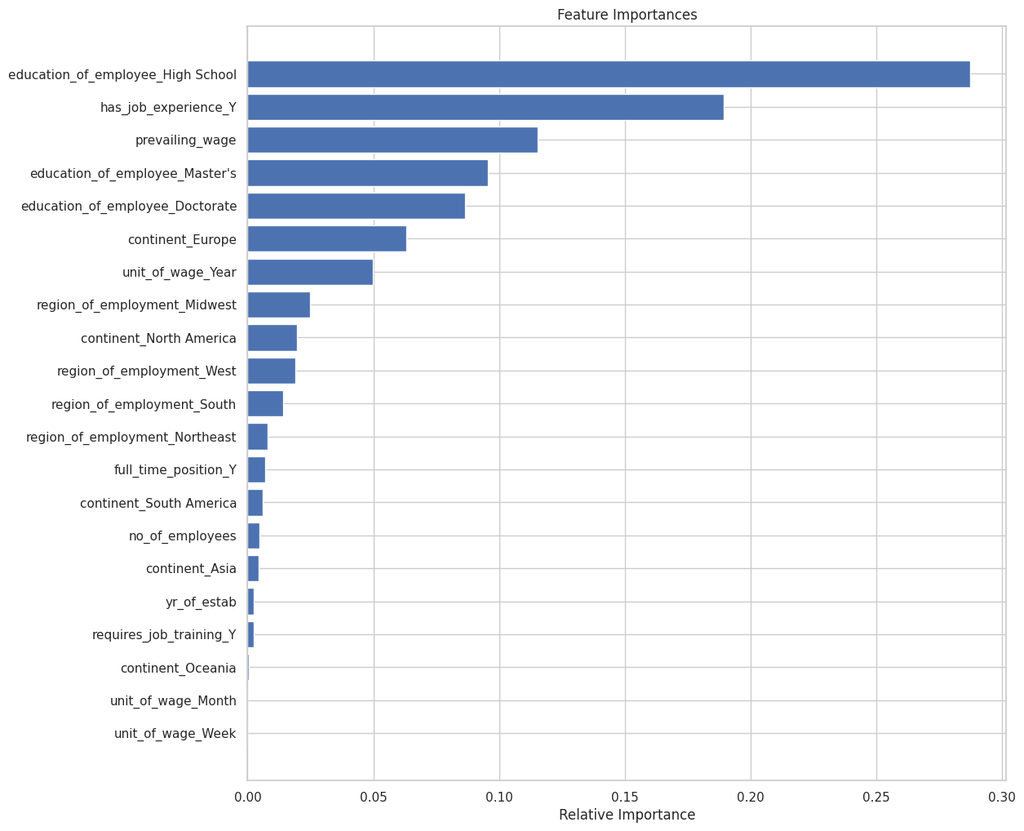

```python
importances = gbcl.feature_importances_
indices = np.argsort(importances)

plt.figure(figsize=(12,12))
plt.title('Feature Importances')
plt.barh(range(len(indices)), importances[indices], align='center')
plt.yticks(range(len(indices)), [feature_names[i] for i in indices])
plt.xlabel('Relative Importance')
plt.show()
```

### Visualization of Decision Tree (tuned)

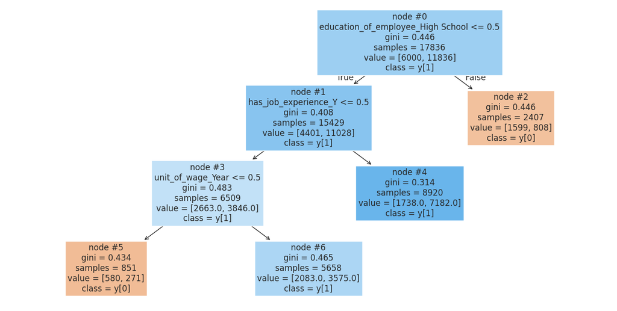

```python
#create visualization of tuned decision-tree model
feature_names = list(X.columns)
plt.figure(figsize=(16,8))
tree.plot_tree(dtree_estimator,feature_names=feature_names,filled=True,fontsize=12,node_ids=True,class_names=True)
plt.show()
```

## Conclusions

#### Insights

For the Office of Foreign Labor Certification (OFLC), the three most critical components for pre-screening an applicant are:

- *Education level*
  - An applicant applying for a job requiring a high school diploma will more than likely be denied. Conversely, applications for jobs requiring a Master's degree or doctorate are very likely to be approved.
- *Prior job experience*
  - An applicant applying for a job without any previous job experience is more likley to be denied than an applicant for a job with experience.
- *Prevailing wage*
  - The higher the prevailing wage of the job an applicant is applying for, the more likely the application will be approved. This is especially true for applications for jobs with an hourly unit of wage.

#### Recommendations

- To prioritize limited resources towards screening a batch of applications for those most likely to be approved, the OFLC can:
  - Sort applications by level of education and review the higher levels of education first.
  - Sort applications by previous job experience and review those with experience first.
  - Divide applications for jobs into those with an hourly wage and those with an annual wage, sort each group by the prevailing wage, then review applications for salaried jobs first from highest to lowest wage.
- As stated previously, the Gradient Boosting classifier performs the best of all the models created. However, as shown above, the tuned Decision-Tree model performs barely worse by F1 score and is a far simpler model. This model may be preferable if post-hoc explanations of OFLC decision-making is expected to be required.
  - Furthermore, OFLC should examine more thoroughly why whether an application will be certified or denied can be very well predicted through just three nodes as shown above.
  - For those in less skilled, entry-level, and/or hourly jobs, the system would appear to be biased against these applications being certified.